# Clustering - K-Means y Jeraquial

En el último cuaderno, aprendimos que los datos se pueden dividir en grupos y aprendimos cómo ver si los datos pueden ser compatibles con dicho análisis. En este cuaderno, realizaremos este agrupamiento automáticamente.

Para comenzar, ejecute la celda a continuación para cargar nuestros datos

> **Cita**: El conjunto de datos de semillas utilizado en este ejercicio fue publicado originalmente por el Instituto de Agrofísica de la Academia de Ciencias de Polonia en Lublin, y se puede descargar del repositorio de conjuntos de datos de la UCI (Dua, D. y Graff, C (2019).Repositorio de aprendizaje automático de UCI [http://archive.ics.uci.edu/ml].Irvine, CA: Universidad de California, Escuela de Información y Ciencias de la Computación).

```python
import pandas as pd
import wget

# load the training dataset
wget.download('https://raw.githubusercontent.com/MicrosoftDocs/mslearn-introduction-to-machine-learning/main/Data/ml-basics/seeds.csv')
data = pd.read_csv('seeds.csv')

# Display a random sample of 10 observations (just the features)
features = data[data.columns[0:6]]
features.sample(10)

from sklearn.preprocessing import MinMaxScaler
from sklearn.decomposition import PCA

# Normalize the numeric features so they're on the same scale
scaled_features = MinMaxScaler().fit_transform(features[data.columns[0:6]])

# Get two principal components
pca = PCA(n_components=2).fit(scaled_features)
features_2d = pca.transform(scaled_features)
features_2d[0:10]
```

```
100% [................................................................................] 9386 / 9386
```

```
array([[ 0.11883593, -0.09382469],
       [ 0.0696878 , -0.31077233],
       [-0.03499184, -0.37044705],
       [-0.06582089, -0.36365235],
       [ 0.32594892, -0.37695797],
       [-0.02455447, -0.31060184],
       [-0.00769646, -0.07594931],
       [-0.05646955, -0.26696284],
       [ 0.38196305, -0.05149471],
       [ 0.35701044, -0.17697998]])
```

## Agrupación de K-Means

El algoritmo que usamos para crear nuestros grupos de prueba es *K-Means*. Este es un algoritmo de agrupación en clústeres de uso común que separa un conjunto de datos en *K* clústeres de igual varianza. El número de clústeres, *K*, lo define el usuario. El algoritmo básico tiene los siguientes pasos:

1. Se elige aleatoriamente un conjunto de K centroides.
2. Los grupos se forman asignando los puntos de datos a su centroide más cercano.
3. Se calculan las medias de cada conglomerado y el centroide se mueve a la media.
4. Los pasos 2 y 3 se repiten hasta que se cumple un criterio de parada. Por lo general, el algoritmo termina cuando cada nueva iteración da como resultado un movimiento insignificante de los centroides y los grupos se vuelven estáticos.
5. Cuando los clústeres dejan de cambiar, el algoritmo *converge*, definiendo las ubicaciones de los clústeres; tenga en cuenta que el punto de inicio aleatorio para los centroides significa que volver a ejecutar el algoritmo podría generar clústeres ligeramente diferentes, por lo que el entrenamiento generalmente involucra múltiples iteraciones, reiniciando los centroides cada vez, y se selecciona el modelo con el mejor WCSS.

Intentemos usar K-Means en nuestros datos de semillas con un valor K de 3.

```python
from sklearn.cluster import KMeans

# Create a model based on 3 centroids
model = KMeans(n_clusters=3, init='k-means++', n_init=100, max_iter=1000)
# Fit to the data and predict the cluster assignments for each data point
km_clusters = model.fit_predict(features.values)
# View the cluster assignments
km_clusters
```

```
array([1, 1, 1, 1, 1, 1, 1, 1, 1, 1, 1, 1, 1, 1, 1, 1, 2, 1, 1, 2, 1, 1,
       1, 1, 1, 1, 2, 1, 1, 1, 1, 1, 1, 1, 1, 1, 1, 0, 1, 2, 1, 1, 1, 1,
       1, 1, 1, 1, 1, 1, 1, 1, 1, 1, 1, 1, 1, 1, 1, 1, 2, 2, 2, 2, 1, 1,
       1, 1, 1, 2, 0, 0, 0, 0, 0, 0, 0, 0, 0, 0, 0, 0, 0, 0, 0, 0, 0, 0,
       0, 0, 0, 0, 0, 0, 0, 0, 0, 0, 0, 0, 1, 0, 0, 0, 0, 0, 0, 0, 0, 0,
       0, 0, 0, 0, 0, 0, 0, 0, 0, 0, 0, 0, 1, 0, 1, 0, 0, 0, 0, 0, 0, 0,
       1, 1, 1, 1, 0, 1, 1, 1, 2, 2, 2, 2, 2, 2, 2, 2, 2, 2, 2, 2, 2, 2,
       2, 2, 2, 2, 2, 2, 2, 2, 2, 2, 2, 2, 2, 2, 2, 2, 2, 2, 2, 2, 2, 2,
       2, 2, 2, 1, 2, 2, 2, 2, 2, 2, 2, 2, 2, 2, 2, 2, 2, 2, 2, 2, 2, 2,
       2, 2, 2, 1, 2, 2, 2, 2, 2, 2, 2, 2])
```

Veamos esas asignaciones de grupos con los puntos de datos bidimensionales.

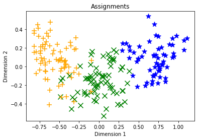

```python
import matplotlib.pyplot as plt
%matplotlib inline

def plot_clusters(samples, clusters):
    col_dic = {0:'blue',1:'green',2:'orange'}
    mrk_dic = {0:'*',1:'x',2:'+'}
    colors = [col_dic[x] for x in clusters]
    markers = [mrk_dic[x] for x in clusters]
    for sample in range(len(clusters)):
        plt.scatter(samples[sample][0], samples[sample][1], color = colors[sample], marker=markers[sample], s=100)
    plt.xlabel('Dimension 1')
    plt.ylabel('Dimension 2')
    plt.title('Assignments')
    plt.show()

plot_clusters(features_2d, km_clusters)
```

Con suerte, los datos se han separado en tres grupos distintos.

Entonces, ¿cuál es el uso práctico de la agrupación? En algunos casos, es posible que tenga datos que necesite agrupar en clústeres distintos sin saber cuántos clústeres hay o qué indican. Por ejemplo, una organización de marketing podría querer separar a los clientes en distintos segmentos y luego investigar cómo esos segmentos exhiben diferentes comportamientos de compra.

A veces, el agrupamiento se usa como un paso inicial hacia la creación de un modelo de clasificación. Comienza identificando distintos grupos de puntos de datos y luego asigna etiquetas de clase a esos grupos. Luego puede usar estos datos etiquetados para entrenar un modelo de clasificación.

En el caso de los datos de semillas, las diferentes especies de semillas ya se conocen y codifican como 0 (Kama), 1 (Rosa) o 2 (Canadian), por lo que podemos usar estos identificadores para comparar las clasificaciones de especies con los grupos identificados. por nuestro algoritmo no supervisado

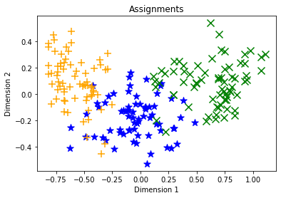

```python
seed_species = data[data.columns[7]]
plot_clusters(features_2d, seed_species.values)
```

Puede haber algunas diferencias entre las asignaciones de conglomerados y las etiquetas de clase, pero el modelo K-Means debería haber hecho un trabajo razonable al agrupar las observaciones para que las semillas de la misma especie estén generalmente en el mismo conglomerado.

## Agrupación jerárquica

Los métodos de agrupamiento jerárquico hacen menos suposiciones de distribución en comparación con los métodos de K-medias. Sin embargo, los métodos de K-medias son generalmente más escalables, a veces mucho más.

La agrupación jerárquica crea grupos mediante un método *divisivo* o un método *aglomerativo*. El método divisivo es un enfoque "de arriba hacia abajo" que comienza con el conjunto de datos completo y luego encuentra particiones de manera escalonada. La agrupación en clústeres aglomerativos es un enfoque de "abajo hacia arriba**". En esta práctica de laboratorio, trabajará con la agrupación en clústeres aglomerativos que funciona aproximadamente de la siguiente manera:

1. Se calculan las distancias de enlace entre cada uno de los puntos de datos.
2. Los puntos se agrupan en pares con su vecino más cercano.
3. Se calculan las distancias de enlace entre los grupos.
4. Los conglomerados se combinan por pares en conglomerados más grandes.
5. Los pasos 3 y 4 se repiten hasta que todos los puntos de datos estén en un solo grupo.

La función de enlace se puede calcular de varias maneras:

- Ward linkage mide el aumento en la varianza de los grupos que se vinculan,
- El enlace promedio utiliza la distancia media por pares entre los miembros de los dos grupos,
- El enlace completo o máximo utiliza la distancia máxima entre los miembros de los dos clústeres.

Se utilizan varias métricas de distancia diferentes para calcular las funciones de enlace:

- La distancia euclidiana o l2 es la más utilizada. Esta métrica es la única opción para el método de vinculación Ward.
- La distancia Manhattan o l1 es robusta frente a valores atípicos y tiene otras propiedades interesantes.
- Semejanza de coseno, es el producto escalar entre los vectores de ubicación dividido por las magnitudes de los vectores. Observe que esta métrica es una medida de similitud, mientras que las otras dos métricas son medidas de diferencia. La similitud puede ser bastante útil cuando se trabaja con datos como imágenes o documentos de texto.

### Clustering aglomerativo

Veamos un ejemplo de agrupamiento de datos de semillas usando un algoritmo de agrupamiento aglomerativo.

```python
from sklearn.cluster import AgglomerativeClustering

agg_model = AgglomerativeClustering(n_clusters=3)
agg_clusters = agg_model.fit_predict(features.values)
agg_clusters
```

```
array([0, 0, 0, 0, 0, 0, 0, 0, 0, 0, 0, 0, 0, 0, 0, 0, 0, 0, 0, 2, 0, 0,
       0, 0, 0, 0, 2, 0, 0, 0, 0, 0, 0, 0, 0, 0, 0, 0, 0, 2, 0, 0, 0, 0,
       0, 0, 0, 0, 0, 0, 0, 0, 0, 0, 0, 0, 0, 0, 0, 0, 0, 0, 2, 0, 0, 0,
       0, 0, 0, 2, 0, 0, 0, 1, 0, 0, 0, 1, 1, 0, 0, 1, 1, 1, 1, 1, 1, 1,
       1, 1, 1, 1, 1, 1, 1, 0, 1, 1, 1, 1, 0, 1, 1, 1, 1, 1, 1, 0, 1, 1,
       1, 1, 1, 1, 1, 1, 1, 1, 1, 1, 1, 0, 0, 1, 0, 1, 1, 1, 1, 0, 1, 1,
       0, 0, 0, 0, 0, 0, 0, 0, 2, 2, 2, 2, 2, 2, 0, 2, 2, 2, 2, 2, 2, 2,
       2, 2, 2, 2, 2, 2, 2, 2, 2, 2, 2, 0, 2, 2, 2, 2, 2, 2, 2, 2, 2, 2,
       2, 2, 2, 0, 2, 2, 2, 2, 2, 2, 2, 2, 2, 2, 2, 2, 2, 2, 2, 2, 2, 0,
       2, 0, 2, 0, 2, 2, 2, 2, 2, 2, 2, 2], dtype=int64)
```

Entonces, ¿cómo son las asignaciones de grupos aglomerativos?

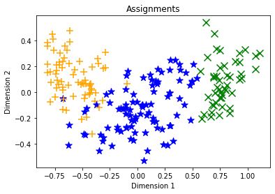

```python
import matplotlib.pyplot as plt

%matplotlib inline

def plot_clusters(samples, clusters):
    col_dic = {0:'blue',1:'green',2:'orange'}
    mrk_dic = {0:'*',1:'x',2:'+'}
    colors = [col_dic[x] for x in clusters]
    markers = [mrk_dic[x] for x in clusters]
    for sample in range(len(clusters)):
        plt.scatter(samples[sample][0], samples[sample][1], color = colors[sample], marker=markers[sample], s=100)
    plt.xlabel('Dimension 1')
    plt.ylabel('Dimension 2')
    plt.title('Assignments')
    plt.show()

plot_clusters(features_2d, agg_clusters)
```

## Summary

Here we practiced using K-means and heirachial clustering. This unsupervised learning has the ability to take unlabelled data and identify which of these data are similar to one another.

## Further Reading

To learn more about clustering with scikit-learn, see the [scikit-learn documentation](https://scikit-learn.org/stable/modules/clustering.html).